# Assignment 1: Probability and Statistics with R

Deepkamal Singh / Deepkamal_Singh_AMPBA2021w@isb.edu

05/10/2020

**Q1 . If a random variable has the normal distribution with μ= 77.0 and σ = 3.4, find the probability that random variable is:**

```
a. less than 72.6
b. greater than 88.5
c. between 81 and 84
d. between 56 and 92
```

*Answer of Q1*

Given its a normal distribution, we establish that

1. 68.2% of observations lie within 1 std deviation of mean,
2. In a normal distribution Z-score Z(X) = (X-μ)/σ

   therefore Z(72.6)

   => Z([(72.6-77)/3.4])

   =>

```r
zVal <- ((72.6-77)/3.4)
zVal
```

```
## [1] -1.294118
```

*Ref Table 1* :: Cumulative Probability Dist function table reference (https://www.itl.nist.gov/div898/handbook/eda/section3/eda3671.htm)

3. let F(X) be Cumulative Distribution Function, such that **F(X)= ΣP(x<X)**
4. With Z score we can use Std Normal prob dist table to derive the prob dist. value, thus we reduce our Normal dist to Standard normal dist by Pt. 2, and we calculate the Z score of our desired value, i.e F(Z(72.6)) = F([(72.6-77)/3.4]) = F([-4.4/3.4]) = F(-1.2941)
5. The probability of random variable is less than 72.6:

   P(X<72.6), Z Score of 72.6 in normal dist where μ=77 and σ=3.4 is Z(72.6)=>(72.6-77)/3.4=> -1.2941, thus F(-1.2941) is probability of occurrence of variable between 0 and the Z score is F(-1.2941) in Standard Normal distribution, therefore F(-1.2941) = F(1.2941), by table 1, F(1.2941) = 0.40147 , And from -ve inf to mean value (0 in std normal distribution) the probability is 0.4999, thus total probability of random variable being less than 72.6 is

   0.4999-0.40147 => **9.84%**
6. Probability that random variable is grater than 88.5

   => P(X>88.5)

   => 1 - (F(Z(88.5)) + F(Z(μ)))

   => 1 -(F([(88.5-77)/3.4])+0.4999)

   => 1 -(F(3.382)+0.4999)

   => By table 1 F(3.382)=0.49964

   thus P(X>88.5) = 1 - (0.49964+0.4999) = 0.00046 i.e **0.04%**
7. Probability that random variable is between 81 and 84:

   P(81<X<84)

   => F(Z(84))-F(Z(81))

   =>F(2.05) - F(1.17)

   => substituting values from table 1 we get

   P(81>X>84)

   => 0.47982 - 0.37900

   => 0.10082

   => **10.08%**
8. Probability that random variable is between 56 and 92:

   P(56<X<92)

   => F([(96-77)/3.4])

   => F(5.5) - F(-6.17)

here, since both variables |Z score| is above 3, which is extreme limit for a normal distribution, we can deduce that **Probability will tend to 1**

*Testing with generated random variables*

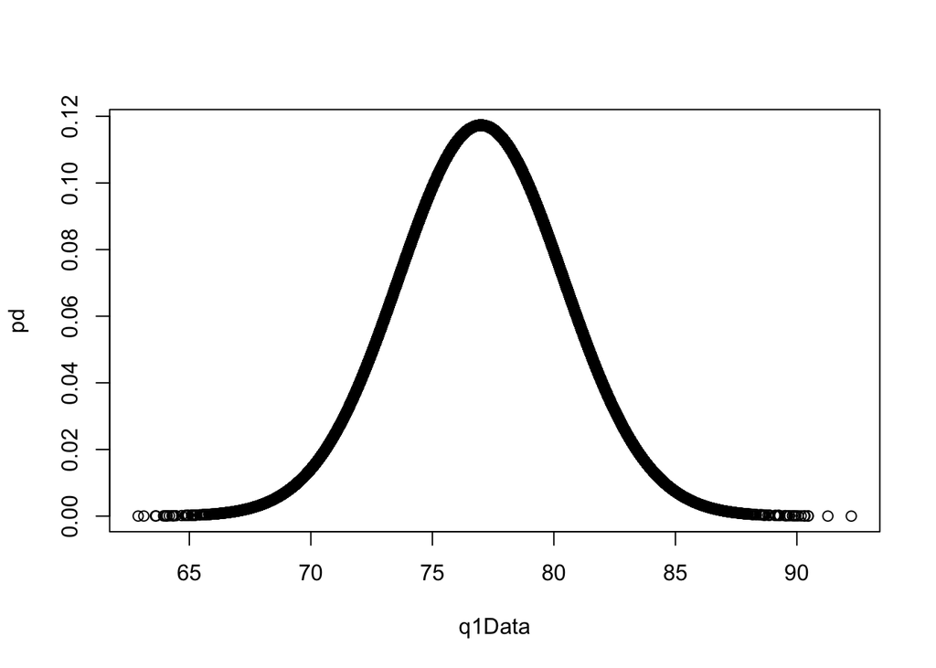

```r
sample_size <-100000
#taking random sample in Normal dist.
q1Data <- rnorm(sample_size,mean=77,sd=3.4)

#taking prob dist in another
pd<-dnorm(q1Data,mean = 77,sd=3.4)

#plot to check distribution - expect bell curve
plot(q1Data,pd)
```

**2. In a car race, the finishing times are normally distributed with mean 145 minutes and standard deviation of 12 minutes.**

```
a. Find percentage of car racers whose finish time is between 130 and 160 minutes.
b. Find percentage of car racers whose finish time is less than 130 minutes.
```

*Answer of Q2*

here mean=145, std=12

1. Find percentage of car racers whose finish time is between 130 and 160 minutes:

   P(130<X<160)

   => F(Z(160)) - F(Z(130))

   => F([160-145]/12) - F([130-145]/12)

   => F(1.25)-F(-1.25)

   => 2 x F(1.25)

   => substituting by Table 1

   => 0.7887

=> **78.87%**

2. Find percentage of car racers whose finish time is less than 130 minutes :

   P(X<130)

   => F(0)+F(Z(130))

   => F(0)+F((130-145)/12)

   => F(0) + F(-1.25)

   => F(0) - F(1.25)

   => By Table1 we substitute values

   => 0.49999-0.39535 = 0.10464

=> *10.46%*

**3. A test-taker has recently taken an aptitude test with 15 questions. All the questions are True/ False type in nature.**

```
a. What is the probability that the student got first five questions correct?
b. What is the probability that the student got five questions correct?
```

*Answer to Q3*

given that Sample Space = 15

number of possible outcomes = Correct/Incorrect = 2

Probability of 1 question being correct = 0.5

[figure not shown]

( *Formula image Courtesy: wikimedia.org* )

here

```
  n=number of trials i.e 15

  p = probability of success in single trial i.e 0.5

  q=probability of failure in single trial

     => 1-p => 0.5,

  k= is number of desired outcomes i.e 5,

  thus

  P(5) = Combination(15,5) x (0.5)^5 x (0.5)^(15-5)

  => Combination(15,5) x (0.5)^15

  =>
```

```r
#Answer of Q3
(factorial(15)/(factorial(5)*factorial(10)) )*((0.5)^15)
```

```
## [1] 0.09164429
```

**4. 68% of the marks in exam are between 35 and 42. Assuming data is normally distributed, what are the mean and standard deviation?**

*Answer of Q4*

Let: mean=$\mu$, Std. deviation=$\sigma$

Given that it is a Normal distribution, 68.2% values lie within ±1 std deviation,

thus $\mu$ + 1x$\sigma$ = 42

AND $\mu$ - 1x$\sigma$ = 35

substituting the values in equation

=> $\mu$ + ($\mu$ - 35) = 42

=> $\mu$ = (42+35)/2 = 38.5

therefore $\sigma$=42-$\mu$=3.5

**5. A professor asked students to take two exams. 30% of the class cleared both exams and 55% of the class cleared the first exam. What percentage of class who cleared first exam also cleared the second exam?**

*Answer to Q5*

```
  Let (A) be the set of students who cleared Exam 1

  given, P(A) = 0.55

  Let (B) be the set of students who cleared Exam 2

  Thus the set of students who cleared both exam are (A$\cap$B)

  given P(A$\cap$B) = 0.3

  To calculate the percentage of class who cleared first exam also cleared the second exam we can formula to derive conditional probability
  which is

  P(B|A) = P(A$\cap$B)/P(A)

  => 0.3/0.55

  => 0.5454
```

i.e *54.54%*

**6. In India, 82% of all urban homes have a TV. 62% have a TV and DVD player. What is probability that a home has a DVD player given that the home has a TV.**

*Answer to Q6*

```
  Let (A) be the set of urban homes that have TV

  given, P(A) = 0.82

  Let (B) be the set of urban homes that have DVD

  Thus the set of urban homes that have both TV and DVD are (A$\cap$B)

  given P(A$\cap$B) = 0.62

  To calculate the probability that a home has a DVD player given that the home has a TV, we will use formula to calculate conditional probability
  which is

  P(B|A) = P(A$\cap$B)/P(A)

  =>  0.62/0.82

  => 0.756
```

i.e *75.6%*

**7. You toss a coin three times. Assume that the coin is fair. What is the probability of getting?**

```
a. All three heads
b. Exactly one head
c. Given that you have seen exactly one head, what is the probability of getting at-least two heads?
```

*Answer of Q7*

```
  Given that coin is fair, thus probability of getting Heads P(H) = 05 = probability of getting Tails P(T) =0.5

  Probability of getting all 3 Heads = P(H) x P(H) x P(H)

  => (0.5)^3
```

=> *0.125*

To calculate Probability of Getting exactly 1 Head, we consider

```
  Sample space => (H or T) and (H or T) and (H orT) => (1+1)x(1+1)x(1+1) = 2x2x2 = 8

  Sample Space of getting just 1 H => HTT or THT or TTH => 1+1+1 = 3

  Thus probability of getting exactly 1 H in three tries of a fair coin toss = ***3/8***


  Now, Given that first toss is head, the probability of getting at-least two heads implies that next two tries can be favorable if HH,HT or TH comes, total sample cases are HH,TT,HT,TH, thus probability comes as 3/4, this is the probability after we know we have exact 1 H (3/8), thus total probability of getting at least 2 Hs given that we already have 1H is
  (3/8)*(3/4) = 9/32
```

=> 0.2812 or **28.12%**

**8. Let x be the random variable that represents the speed of cars. x has μ = 90 and σ = 10. We must find the probability that x is higher than 100 or P(x > 100)**

Given mean = 90, std = 10,

As distribution of variable x is not specified, thus we can NOT calculate probability that x is higher than 100,

However assuming its a *Normal distribution* -

```
  P(x > 100 ) = 1-pnorm(100,mean=90,std=10)
```

=>

```r
#Answer of Q8
cat((1-pnorm(100,mean=90,sd=10))*100,"%")
```

```
## 15.86553 %
```

**9. The blue M&M was introduced in 1995. Before then, the color mix in a bag of plain M&Ms was (30% Brown, 20% Yellow, 20% Red, 10% Green, 10% Orange, 10% Tan). Afterward it was (24% Blue, 20% Green, 16% Orange, 14% Yellow, 13% Red, 13% Brown). A friend of mine has two bags of M&Ms, and he tells me that one is from 1994 and one from 1996. He will not tell me, which is which, but he gives me one M&M from each bag. One is yellow and one is green. What is the probability that the yellow M&M came from the 1994 bag?**

Given that:

Before 1995, in a Bag of M&M

P(Br)=30% => 0.3

P(Y) = 0.2

P(R) = 0.2

P(G) = 0.1

P(O) = 0.1

P(T) = 0.1

P(Bl)= 0.0

After 1995

P(Bl)= 0.24

P(Br) = 0.13

P(Y) = 0.14

P(R) = 0.13

P(G) = 0.20

P(O) = 0.16

P(T) = 0.0

Let the Bags be named B1 and B2

since likelihood of choosing any bag between B1 and B2 is same,i.e 0.5

now, if Bag chosen is from 1994,

```
  probability of getting Yellow from Bag1 P(Y) = 0.2 and Green from Bag2 P(G)=0.2

  total probability = 0.2 x 0.2 = 0.04

  Since bag1 is chosen, total probability with Bag1 P(B1)= 0.5 x 0.04 = 0.02
```

alternatively,

[output not shown]

**10. Find the daily stock price of Wal-Mart for the last three months. (A good source for the data is http://moneycentral.msn.com or Yahoo Finance or Google Finance (there are many more such sources). You can ask for the three-month chart and export the data to a spreadsheet.)**

```
a. Calculate the mean and the standard deviation of the stock prices.
b. Get the corresponding data for Kmart and calculate the mean and the standard deviation.
c. The coefficient of variation (CV) is defined as the ratio of the standard deviation over the mean. Calculate the CV of Wal-Mart and Kmart stock prices.
d. If the CV of the daily stock prices is taken as an indicator of risk of the stock, how do Wal-Mart and Kmart stocks compare in terms of risk? (There are better measures of risk, but we will use CV in this exercise.)
e. Get the corresponding data of the Dow Jones Industrial Average (DJIA) and compute its CV. How do Wal- Mart and Kmart stocks compare with the DJIA in terms of risk?
f. Suppose you bought 100 shares of Wal‐Mart stock three months ago and held it. What are the mean and the standard deviation of the daily market price of your holding for the three months?
```

`Note: Question referenced from Aczel A., Sounderpandian J., Complete Business Statistics (7ed.)`

```r
#Answer of Q10

#data downloaded from MSN - https://www.msn.com/en-us/money/stockdetails/history/nys-wmt/fi-a25ya2, and saved in file wmt.csv

setwd("~/Desktop/")

walmartData <- read.csv('wmt.csv',header=TRUE,colClasses=c("Date"="Date","High"="double","Low"="double","Open"="double","Close"="double","Volume"="double"))
str(walmartData)
```

```
## 'data.frame':    76 obs. of  6 variables:
##  $ Date  : Date, format: "0016-10-20" "0015-10-20" ...
##  $ High  : num  146 145 147 147 145 ...
##  $ Low   : num  144 143 144 144 143 ...
##  $ Open  : num  145 143 146 145 143 ...
##  $ Close : num  145 145 144 146 144 ...
##  $ Volume: num  5634821 4557421 6554539 7916288 6096005 ...
```

```r
kable(walmartData, caption="walmart Stock Data (source: https://www.msn.com/en-us/money/stockdetails/history/nys-wmt/fi-a25ya2)")
```

walmart Stock Data (source: https://www.msn.com/en-us/money/stockdetails/history/nys-wmt/fi-a25ya2)

| Date | High | Low | Open | Close | Volume |
| --- | --- | --- | --- | --- | --- |
| 0016-10-20 | 146.15 | 144.47 | 145.40 | 144.71 | 5634821 |
| 0015-10-20 | 144.96 | 142.84 | 143.09 | 144.53 | 4557421 |
| 0014-10-20 | 146.53 | 143.76 | 146.40 | 143.94 | 6554539 |
| 0013-10-20 | 146.60 | 144.36 | 144.68 | 146.23 | 7916288 |
| 0012-10-20 | 145.39 | 143.02 | 143.02 | 144.25 | 6096005 |
| 0009-10-20 | 143.34 | 141.56 | 141.66 | 142.78 | 4802885 |
| 0008-10-20 | 142.09 | 141.12 | 141.51 | 141.36 | 4878011 |
| 0007-10-20 | 141.55 | 140.25 | 141.26 | 140.89 | 5618996 |
| 0006-10-20 | 142.94 | 140.25 | 141.87 | 140.63 | 7132823 |
| 0005-10-20 | 142.19 | 141.07 | 141.29 | 141.80 | 4642737 |
| 0002-10-20 | 143.10 | 140.13 | 142.34 | 140.50 | 8148375 |
| 0001-10-20 | 144.38 | 140.26 | 140.80 | 143.08 | 14377639 |
| 0030-09-20 | 141.74 | 137.20 | 137.39 | 139.91 | 11582185 |
| 0029-09-20 | 138.14 | 136.39 | 137.25 | 137.14 | 9224037 |
| 0028-09-20 | 138.05 | 136.72 | 137.16 | 137.25 | 6876969 |
| 0025-09-20 | 137.54 | 135.96 | 136.52 | 137.27 | 7485518 |
| 0024-09-20 | 137.79 | 135.07 | 135.73 | 136.70 | 9734787 |
| 0023-09-20 | 139.24 | 135.82 | 139.00 | 135.99 | 7686835 |
| 0022-09-20 | 138.99 | 136.57 | 137.07 | 138.31 | 11013242 |
| 0021-09-20 | 137.24 | 135.29 | 136.50 | 137.07 | 15700245 |
| 0018-09-20 | 137.53 | 134.75 | 136.44 | 135.29 | 18124285 |
| 0017-09-20 | 137.57 | 135.02 | 135.43 | 136.69 | 12291905 |
| 0016-09-20 | 138.68 | 136.05 | 138.41 | 136.26 | 9273405 |
| 0015-09-20 | 139.08 | 136.68 | 138.23 | 137.36 | 10065154 |
| 0014-09-20 | 141.10 | 135.88 | 136.14 | 137.32 | 15187066 |
| 0011-09-20 | 138.44 | 135.55 | 137.05 | 136.70 | 9588878 |
| 0010-09-20 | 140.54 | 136.59 | 140.06 | 136.81 | 11196376 |
| 0009-09-20 | 142.61 | 139.45 | 140.09 | 139.89 | 11168450 |
| 0008-09-20 | 141.90 | 138.26 | 141.41 | 138.45 | 11232656 |
| 0004-09-20 | 145.04 | 140.10 | 144.02 | 142.83 | 11246616 |
| 0003-09-20 | 149.60 | 141.81 | 146.70 | 144.54 | 15761694 |
| 0002-09-20 | 151.33 | 145.61 | 151.25 | 147.68 | 17042512 |
| 0001-09-20 | 149.59 | 140.05 | 141.20 | 147.59 | 35197349 |
| 0031-08-20 | 138.89 | 135.53 | 137.48 | 138.85 | 14876406 |
| 0028-08-20 | 141.07 | 137.84 | 141.00 | 140.30 | 21229446 |
| 0027-08-20 | 139.35 | 130.90 | 131.08 | 136.63 | 39170257 |
| 0026-08-20 | 130.88 | 129.70 | 130.21 | 130.70 | 6231982 |
| 0025-08-20 | 131.24 | 129.67 | 130.80 | 130.63 | 7220754 |
| 0024-08-20 | 132.48 | 130.33 | 132.25 | 131.33 | 6521383 |
| 0021-08-20 | 132.67 | 130.10 | 130.55 | 131.63 | 8122046 |
| 0020-08-20 | 132.07 | 130.05 | 131.21 | 130.57 | 8884401 |
| 0019-08-20 | 134.66 | 131.85 | 134.21 | 132.41 | 12664141 |
| 0018-08-20 | 137.63 | 133.17 | 136.17 | 134.71 | 26662892 |
| 0017-08-20 | 136.13 | 133.85 | 134.35 | 135.60 | 12721575 |
| 0014-08-20 | 132.97 | 131.63 | 132.34 | 132.60 | 6671007 |
| 0013-08-20 | 131.96 | 130.73 | 131.21 | 131.85 | 6588367 |
| 0012-08-20 | 132.23 | 129.08 | 130.47 | 131.89 | 6334740 |
| 0011-08-20 | 132.87 | 129.73 | 132.59 | 130.20 | 8430741 |
| 0010-08-20 | 132.34 | 129.65 | 130.24 | 131.88 | 5841097 |
| 0007-08-20 | 130.46 | 129.11 | 129.58 | 129.97 | 5380121 |
| 0006-08-20 | 130.23 | 129.03 | 129.13 | 129.35 | 4818016 |
| 0005-08-20 | 130.75 | 128.83 | 130.45 | 129.81 | 8482426 |
| 0004-08-20 | 131.71 | 128.94 | 129.65 | 131.64 | 5863118 |
| 0003-08-20 | 130.12 | 128.27 | 129.91 | 129.30 | 4982869 |
| 0031-07-20 | 130.09 | 127.62 | 129.65 | 129.40 | 7163661 |
| 0030-07-20 | 130.42 | 128.72 | 129.42 | 130.12 | 4562933 |
| 0029-07-20 | 131.86 | 129.85 | 131.56 | 130.69 | 4718533 |
| 0028-07-20 | 132.38 | 130.92 | 131.50 | 131.76 | 4786689 |
| 0027-07-20 | 131.98 | 130.86 | 130.86 | 131.21 | 4388366 |
| 0024-07-20 | 132.40 | 130.51 | 130.95 | 131.24 | 4300294 |
| 0023-07-20 | 133.15 | 131.31 | 133.00 | 131.64 | 5573420 |
| 0022-07-20 | 133.03 | 131.19 | 132.57 | 132.66 | 5388177 |
| 0021-07-20 | 133.99 | 131.45 | 131.56 | 132.33 | 7213505 |
| 0020-07-20 | 132.74 | 131.14 | 131.96 | 131.47 | 6080969 |
| 0017-07-20 | 133.37 | 131.47 | 133.37 | 131.74 | 6023302 |
| 0016-07-20 | 132.73 | 131.24 | 132.05 | 132.20 | 5829154 |
| 0015-07-20 | 134.13 | 130.80 | 132.27 | 132.00 | 10513628 |
| 0014-07-20 | 132.50 | 129.03 | 129.28 | 132.01 | 8818555 |
| 0013-07-20 | 133.63 | 128.89 | 131.33 | 129.52 | 14035826 |
| 0010-07-20 | 131.37 | 127.26 | 128.74 | 130.68 | 14531853 |
| 0009-07-20 | 128.18 | 124.95 | 125.61 | 127.75 | 14257238 |
| 0008-07-20 | 128.13 | 124.40 | 128.00 | 124.44 | 17270243 |
| 0007-07-20 | 127.55 | 118.22 | 118.45 | 126.95 | 30817871 |
| 0006-07-20 | 119.87 | 118.22 | 119.80 | 118.89 | 7202166 |
| 0002-07-20 | 120.88 | 118.86 | 120.09 | 119.21 | 5886199 |
| 0001-07-20 | 119.92 | 118.66 | 119.45 | 119.69 | 6577921 |

we will consider column “Close” as Stock price

*a. Calculate the mean and the standard deviation of the stock prices:*

```r
   wmt.meanOfStockPrice = mean(walmartData[["Close"]])
   wmt.meanOfStockPrice
```

```
## [1] 134.8842
```

```r
   wmt.stdDeviation =  sd(walmartData[["Close"]])
   wmt.stdDeviation
```

```
## [1] 6.217264
```

*b. Get the corresponding data for Kmart and calculate the mean and the standard deviation.*

Since KMart is not available anymore, we are choosing Target - TGT stock symbol

```r
   #data downloaded from MSN - https://www.msn.com/en-us/money/stockdetails/history/nys-tgt/fi-a246z2, and saved in file tgt.csv

#Date,High,Low,Open,Close,Volume
targetData <- read.csv('tgt.csv',header=TRUE,colClasses=c("Date"="Date","High"="double","Low"="double","Open"="double","Close"="double","Volume"="double"))
str(targetData)
```

```
## 'data.frame':    76 obs. of  6 variables:
##  $ Date  : Date, format: "0016-10-20" "0015-10-20" ...
##  $ High  : num  167 165 166 167 165 ...
##  $ Low   : num  164 161 163 164 164 ...
##  $ Open  : num  166 162 166 165 164 ...
##  $ Close : num  165 165 164 166 165 ...
##  $ Volume: num  4823492 1857424 2246987 2012192 2419376 ...
```

```r
kable(targetData, caption="Target Stock Data (source: https://www.msn.com/en-us/money/stockdetails/history/nys-wmt/fi-a25ya2)")
```

| Date | High | Low | Open | Close | Volume |
| --- | --- | --- | --- | --- | --- |
| 0016-10-20 | 167.25 | 164.36 | 165.91 | 164.92 | 4823492 |
| 0015-10-20 | 165.46 | 161.12 | 161.84 | 165.46 | 1857424 |
| 0014-10-20 | 166.16 | 162.60 | 165.98 | 163.97 | 2246987 |
| 0013-10-20 | 166.68 | 164.15 | 164.57 | 165.64 | 2012192 |
| 0012-10-20 | 165.49 | 163.62 | 164.30 | 164.57 | 2419376 |
| 0009-10-20 | 164.81 | 162.10 | 162.20 | 163.71 | 2575747 |
| 0008-10-20 | 163.32 | 161.39 | 162.60 | 161.86 | 2176002 |
| 0007-10-20 | 161.61 | 159.61 | 160.06 | 160.68 | 2925854 |
| 0006-10-20 | 161.98 | 157.61 | 161.47 | 158.41 | 2905826 |
| 0005-10-20 | 162.31 | 159.99 | 159.99 | 161.49 | 2247000 |
| 0002-10-20 | 159.99 | 156.16 | 156.97 | 159.10 | 1955054 |
| 0001-10-20 | 160.89 | 158.10 | 158.41 | 158.60 | 3847237 |
| 0030-09-20 | 159.15 | 156.50 | 157.45 | 157.42 | 2786142 |
| 0029-09-20 | 158.43 | 155.87 | 156.75 | 156.94 | 2772512 |
| 0028-09-20 | 157.71 | 154.65 | 154.95 | 156.46 | 3616553 |
| 0025-09-20 | 155.16 | 151.75 | 151.86 | 154.35 | 2736871 |
| 0024-09-20 | 153.56 | 150.10 | 151.62 | 152.00 | 3213123 |
| 0023-09-20 | 155.20 | 150.37 | 153.88 | 151.01 | 2786922 |
| 0022-09-20 | 154.44 | 150.93 | 151.15 | 154.08 | 4268659 |
| 0021-09-20 | 149.99 | 146.45 | 148.69 | 149.86 | 3255840 |
| 0018-09-20 | 149.52 | 147.26 | 147.72 | 148.82 | 3523253 |
| 0017-09-20 | 148.77 | 146.55 | 147.39 | 147.61 | 2368883 |
| 0016-09-20 | 149.73 | 147.91 | 149.34 | 147.99 | 2052353 |
| 0015-09-20 | 149.84 | 147.36 | 148.11 | 149.07 | 2150333 |
| 0014-09-20 | 150.39 | 147.84 | 148.55 | 148.44 | 2637721 |
| 0011-09-20 | 147.96 | 146.18 | 146.86 | 147.65 | 2261723 |
| 0010-09-20 | 148.34 | 145.31 | 147.60 | 146.04 | 2761945 |
| 0009-09-20 | 148.60 | 144.76 | 144.76 | 147.55 | 3270925 |
| 0008-09-20 | 146.79 | 143.38 | 146.68 | 144.00 | 3477732 |
| 0004-09-20 | 148.55 | 143.69 | 146.69 | 147.23 | 4720916 |
| 0003-09-20 | 149.98 | 145.41 | 149.47 | 146.03 | 4083844 |
| 0002-09-20 | 150.87 | 148.42 | 150.50 | 149.84 | 4083710 |
| 0001-09-20 | 151.77 | 150.12 | 150.61 | 150.55 | 3583511 |
| 0031-08-20 | 151.91 | 150.32 | 151.14 | 151.21 | 3015394 |
| 0028-08-20 | 151.67 | 149.60 | 150.31 | 150.85 | 2775396 |
| 0027-08-20 | 152.75 | 149.67 | 152.66 | 150.31 | 3589256 |
| 0026-08-20 | 153.57 | 152.09 | 152.75 | 152.71 | 2387711 |
| 0025-08-20 | 154.28 | 152.36 | 154.15 | 152.85 | 2924091 |
| 0024-08-20 | 154.62 | 152.63 | 154.50 | 153.24 | 4349175 |
| 0021-08-20 | 155.61 | 152.13 | 152.33 | 153.63 | 6998193 |
| 0020-08-20 | 156.10 | 151.72 | 154.93 | 152.24 | 12021539 |
| 0019-08-20 | 154.69 | 146.54 | 148.50 | 154.22 | 39839211 |
| 0018-08-20 | 137.97 | 134.67 | 137.01 | 136.90 | 5667948 |
| 0017-08-20 | 138.69 | 137.40 | 137.98 | 138.24 | 4578144 |
| 0014-08-20 | 137.00 | 135.22 | 135.92 | 136.53 | 3117842 |
| 0013-08-20 | 134.94 | 133.61 | 133.99 | 134.81 | 2320996 |
| 0012-08-20 | 135.11 | 132.77 | 135.11 | 134.60 | 4843473 |
| 0011-08-20 | 134.59 | 131.35 | 133.71 | 131.72 | 3797460 |
| 0010-08-20 | 134.11 | 131.25 | 132.07 | 132.94 | 2959399 |
| 0007-08-20 | 131.88 | 129.00 | 129.24 | 131.75 | 2263170 |
| 0006-08-20 | 129.93 | 128.13 | 129.50 | 129.01 | 1979028 |
| 0005-08-20 | 131.93 | 128.66 | 130.75 | 129.37 | 3688346 |
| 0004-08-20 | 130.77 | 127.58 | 127.93 | 130.45 | 3802113 |
| 0003-08-20 | 128.24 | 126.25 | 126.50 | 127.84 | 3294728 |
| 0031-07-20 | 125.93 | 123.79 | 124.28 | 125.88 | 3238266 |
| 0030-07-20 | 125.42 | 121.82 | 122.33 | 124.58 | 3599041 |
| 0029-07-20 | 124.48 | 122.90 | 123.47 | 123.68 | 2043792 |
| 0028-07-20 | 124.46 | 122.12 | 122.61 | 123.29 | 2311272 |
| 0027-07-20 | 124.49 | 122.16 | 124.25 | 122.69 | 2351238 |
| 0024-07-20 | 125.53 | 122.06 | 122.54 | 123.71 | 3815041 |
| 0023-07-20 | 123.60 | 121.94 | 123.45 | 122.35 | 3261186 |
| 0022-07-20 | 123.18 | 120.00 | 120.30 | 123.14 | 3846862 |
| 0021-07-20 | 120.99 | 120.02 | 120.35 | 120.20 | 3190582 |
| 0020-07-20 | 121.87 | 119.04 | 121.54 | 119.82 | 3766320 |
| 0017-07-20 | 123.21 | 121.45 | 122.64 | 121.67 | 2658013 |
| 0016-07-20 | 122.99 | 121.14 | 121.26 | 121.95 | 3108898 |
| 0015-07-20 | 122.72 | 120.01 | 121.31 | 121.67 | 3528750 |
| 0014-07-20 | 120.17 | 117.42 | 118.74 | 120.08 | 2578213 |
| 0013-07-20 | 121.76 | 118.38 | 119.38 | 118.73 | 3456092 |
| 0010-07-20 | 118.98 | 117.06 | 117.82 | 118.86 | 2025599 |
| 0009-07-20 | 119.31 | 117.13 | 117.46 | 117.90 | 2861115 |
| 0008-07-20 | 118.50 | 116.73 | 118.15 | 117.70 | 2831307 |
| 0007-07-20 | 119.55 | 117.81 | 118.30 | 118.06 | 3899692 |
| 0006-07-20 | 120.25 | 117.98 | 120.01 | 119.24 | 3615899 |
| 0002-07-20 | 120.59 | 118.89 | 119.98 | 119.12 | 2203191 |
| 0001-07-20 | 120.36 | 118.83 | 119.91 | 118.96 | 2834738 |

```r
#Now we calculate Mean and Std deviation of "Close" column

tgt.meanOfStockPrice <- mean(targetData[["Close"]])
cat("Mean Stock price for TGT",tgt.meanOfStockPrice)
```

```
## Mean Stock price for TGT 141.1849
```

```r
tgt.stdDeviation <- sd(targetData[["Close"]])

cat("Std Dev Stock price for TGT",tgt.stdDeviation)
```

```
## Std Dev Stock price for TGT 15.73367
```

```
  c. The coefficient of variation (CV) is defined as the ratio of the standard deviation over the mean. Calculate the CV of Wal-Mart and Target stock prices.
```

```r
   wmt.CV = (wmt.stdDeviation/wmt.meanOfStockPrice)
   cat("walmart coefficient of variance for Stock price is ",wmt.CV)
```

```
## walmart coefficient of variance for Stock price is  0.04609334
```

```r
   tgt.CV = (tgt.stdDeviation/tgt.meanOfStockPrice)
   cat("Target coefficient of variance for Stock price is ",tgt.CV)
```

```
## Target coefficient of variance for Stock price is  0.1114402
```

```
  d. If the CV of the daily stock prices is taken as an indicator of risk of the stock, how do Wal-Mart and Kmart stocks compare in terms of risk? (There are better measures of risk, but we will use CV in this exercise.)
```

```r
cat("CV of walmart is ",(if(wmt.CV>tgt.CV) "Greater Than" else "Lower Than"), " CV of target")
```

```
## CV of walmart is  Lower Than  CV of target
```

*Comparing the Coeff of Variance of walmart and Target we find that, walmart CV is lower than target CV, since CV is ratio of mean and std dev - this means walmart stock price fluctuates less from the centrality of stock price as compared to Target stock price.*

```
  e. Get the corresponding data of the Dow Jones Industrial Average (DJIA) and compute its CV. How do Wal- Mart and Kmart stocks compare with the DJIA in terms of risk?
```

```r
# loading data of DJIA

   #data downloaded from MSN - https://www.msn.com/en-us/money/stockdetails/history/nys-tgt/fi-a246z2, and saved in file tgt.csv

#Date,High,Low,Open,Adj Close, Close,Volume
djiData <- read.csv('DJI.csv',header=TRUE,colClasses=c("Date"="Date","High"="double","Low"="double","Open"="double","AdjClose"="double","Close"="double","Volume"="double"))
str(djiData)
```

```
## 'data.frame':    76 obs. of  7 variables:
##  $ Date    : Date, format: "0016-10-20" "0015-10-20" ...
##  $ Open    : num  28571 28323 28731 28765 28671 ...
##  $ High    : num  28843 28536 28793 28809 28958 ...
##  $ Low     : num  28571 28182 28462 28604 28660 ...
##  $ Close   : num  28606 28494 28514 28680 28838 ...
##  $ AdjClose: num  28606 28494 28514 28680 28838 ...
##  $ Volume  : num  3.56e+08 3.29e+08 3.71e+08 5.26e+08 4.94e+08 ...
```

```r
kable(djiData, caption="Dow Jone Stock Data (source: https://finance.yahoo.com/quote/%5EDJI/history?p=%5EDJI)")
```

Dow Jone Stock Data (source: https://finance.yahoo.com/quote/%5EDJI/history?p=%5EDJI)

| Date | Open | High | Low | Close | AdjClose | Volume |
| --- | --- | --- | --- | --- | --- | --- |
| 0016-10-20 | 28570.72 | 28842.90 | 28570.72 | 28606.31 | 28606.31 | 356140000 |
| 0015-10-20 | 28323.40 | 28535.85 | 28181.54 | 28494.20 | 28494.20 | 328940000 |
| 0014-10-20 | 28731.30 | 28792.56 | 28461.73 | 28514.00 | 28514.00 | 370800000 |
| 0013-10-20 | 28764.95 | 28808.84 | 28604.35 | 28679.81 | 28679.81 | 526110000 |
| 0012-10-20 | 28671.12 | 28957.90 | 28659.67 | 28837.52 | 28837.52 | 493680000 |
| 0009-10-20 | 28533.61 | 28676.29 | 28440.63 | 28586.90 | 28586.90 | 324050000 |
| 0008-10-20 | 28348.86 | 28459.13 | 28265.56 | 28425.51 | 28425.51 | 314750000 |
| 0007-10-20 | 27971.36 | 28369.66 | 27971.36 | 28303.46 | 28303.46 | 328750000 |
| 0006-10-20 | 28214.24 | 28354.48 | 27728.03 | 27772.76 | 27772.76 | 435030000 |
| 0005-10-20 | 27825.42 | 28162.64 | 27825.42 | 28148.64 | 28148.64 | 318210000 |
| 0002-10-20 | 27536.39 | 27861.43 | 27382.94 | 27682.81 | 27682.81 | 392770000 |
| 0001-10-20 | 27940.63 | 28041.46 | 27669.26 | 27816.90 | 27816.90 | 373450000 |
| 0030-09-20 | 27514.64 | 28026.33 | 27511.06 | 27781.70 | 27781.70 | 452550000 |
| 0029-09-20 | 27560.24 | 27605.60 | 27338.09 | 27452.66 | 27452.66 | 303820000 |
| 0028-09-20 | 27362.14 | 27722.60 | 27362.14 | 27584.06 | 27584.06 | 401860000 |
| 0025-09-20 | 26694.51 | 27239.29 | 26635.38 | 27173.96 | 27173.96 | 388900000 |
| 0024-09-20 | 26716.09 | 27094.85 | 26537.01 | 26815.44 | 26815.44 | 447810000 |
| 0023-09-20 | 27413.60 | 27464.46 | 26716.12 | 26763.13 | 26763.13 | 459470000 |
| 0022-09-20 | 27170.34 | 27333.09 | 26989.93 | 27288.18 | 27288.18 | 420720000 |
| 0021-09-20 | 27484.71 | 27484.71 | 26715.15 | 27147.70 | 27147.70 | 523660000 |
| 0018-09-20 | 27864.87 | 27946.69 | 27487.97 | 27657.42 | 27657.42 | 698710000 |
| 0017-09-20 | 27834.18 | 28056.79 | 27647.93 | 27901.98 | 27901.98 | 437230000 |
| 0016-09-20 | 28031.69 | 28364.77 | 28021.67 | 28032.38 | 28032.38 | 416650000 |
| 0015-09-20 | 28139.76 | 28231.06 | 27931.45 | 27995.60 | 27995.60 | 414520000 |
| 0014-09-20 | 27718.74 | 28086.06 | 27718.74 | 27993.33 | 27993.33 | 380750000 |
| 0011-09-20 | 27613.86 | 27828.82 | 27448.15 | 27665.64 | 27665.64 | 435330000 |
| 0010-09-20 | 28022.51 | 28174.78 | 27447.08 | 27534.58 | 27534.58 | 442850000 |
| 0009-09-20 | 27711.71 | 28206.21 | 27704.54 | 27940.47 | 27940.47 | 460590000 |
| 0008-09-20 | 27925.23 | 27925.23 | 27464.90 | 27500.89 | 27500.89 | 580860000 |
| 0004-09-20 | 28341.05 | 28539.75 | 27664.68 | 28133.31 | 28133.31 | 694640000 |
| 0003-09-20 | 29090.70 | 29199.35 | 28074.76 | 28292.73 | 28292.73 | 650080000 |
| 0002-09-20 | 28736.79 | 29162.88 | 28713.53 | 29100.50 | 29100.50 | 539510000 |
| 0001-09-20 | 28439.61 | 28659.26 | 28290.72 | 28645.66 | 28645.66 | 423410000 |
| 0031-08-20 | 28643.66 | 28643.66 | 28363.55 | 28430.05 | 28430.05 | 517320000 |
| 0028-08-20 | 28601.29 | 28733.35 | 28487.98 | 28653.87 | 28653.87 | 369740000 |
| 0027-08-20 | 28384.07 | 28634.22 | 28363.93 | 28492.27 | 28492.27 | 404340000 |
| 0026-08-20 | 28257.88 | 28353.80 | 28153.91 | 28331.92 | 28331.92 | 327070000 |
| 0025-08-20 | 28347.42 | 28400.74 | 28094.57 | 28248.44 | 28248.44 | 338420000 |
| 0024-08-20 | 28077.58 | 28314.94 | 28041.75 | 28308.46 | 28308.46 | 383880000 |
| 0021-08-20 | 27758.13 | 27959.48 | 27686.78 | 27930.33 | 27930.33 | 372720000 |
| 0020-08-20 | 27622.68 | 27781.46 | 27526.25 | 27739.73 | 27739.73 | 304550000 |
| 0019-08-20 | 27811.26 | 27920.42 | 27647.67 | 27692.88 | 27692.88 | 311460000 |
| 0018-08-20 | 27853.48 | 27891.12 | 27668.79 | 27778.07 | 27778.07 | 276170000 |
| 0017-08-20 | 27970.05 | 27999.81 | 27816.40 | 27844.91 | 27844.91 | 286860000 |
| 0014-08-20 | 27828.93 | 27977.81 | 27759.39 | 27931.02 | 27931.02 | 275540000 |
| 0013-08-20 | 27922.51 | 27986.10 | 27789.78 | 27896.72 | 27896.72 | 360160000 |
| 0012-08-20 | 27860.24 | 28043.89 | 27843.32 | 27976.84 | 27976.84 | 340210000 |
| 0011-08-20 | 27961.64 | 28154.88 | 27624.51 | 27686.91 | 27686.91 | 428220000 |
| 0010-08-20 | 27488.21 | 27803.86 | 27488.21 | 27791.44 | 27791.44 | 360340000 |
| 0007-08-20 | 27321.68 | 27456.24 | 27223.55 | 27433.48 | 27433.48 | 321170000 |
| 0006-08-20 | 27170.82 | 27394.10 | 27145.25 | 27386.98 | 27386.98 | 322460000 |
| 0005-08-20 | 26924.78 | 27221.67 | 26924.78 | 27201.52 | 27201.52 | 366000000 |
| 0004-08-20 | 26664.61 | 26832.72 | 26597.82 | 26828.47 | 26828.47 | 346350000 |
| 0003-08-20 | 26542.32 | 26707.26 | 26534.38 | 26664.40 | 26664.40 | 439380000 |
| 0031-07-20 | 26409.33 | 26440.02 | 26013.59 | 26428.32 | 26428.32 | 488050000 |
| 0030-07-20 | 26367.42 | 26374.93 | 25992.28 | 26313.65 | 26313.65 | 351540000 |
| 0029-07-20 | 26388.44 | 26602.45 | 26375.39 | 26539.57 | 26539.57 | 347580000 |
| 0028-07-20 | 26529.45 | 26556.84 | 26361.71 | 26379.28 | 26379.28 | 361090000 |
| 0027-07-20 | 26447.67 | 26625.46 | 26426.92 | 26584.77 | 26584.77 | 400930000 |
| 0024-07-20 | 26533.41 | 26625.70 | 26402.86 | 26469.89 | 26469.89 | 494170000 |
| 0023-07-20 | 26955.97 | 26973.85 | 26560.04 | 26652.33 | 26652.33 | 419800000 |
| 0022-07-20 | 26824.56 | 27035.24 | 26794.19 | 27005.84 | 27005.84 | 404340000 |
| 0021-07-20 | 26833.14 | 27025.38 | 26766.22 | 26840.40 | 26840.40 | 364930000 |
| 0020-07-20 | 26660.29 | 26765.02 | 26504.20 | 26680.87 | 26680.87 | 309390000 |
| 0017-07-20 | 26774.62 | 26808.43 | 26619.88 | 26671.95 | 26671.95 | 296460000 |
| 0016-07-20 | 26746.57 | 26879.16 | 26590.01 | 26734.71 | 26734.71 | 287330000 |
| 0015-07-20 | 27009.81 | 27071.33 | 26692.48 | 26870.10 | 26870.10 | 384900000 |
| 0014-07-20 | 26044.17 | 26690.52 | 25994.98 | 26642.59 | 26642.59 | 401640000 |
| 0013-07-20 | 26225.07 | 26639.09 | 26044.23 | 26085.80 | 26085.80 | 425320000 |
| 0010-07-20 | 25690.35 | 26101.32 | 25637.50 | 26075.30 | 26075.30 | 338170000 |
| 0009-07-20 | 26094.92 | 26103.28 | 25523.51 | 25706.09 | 25706.09 | 387610000 |
| 0008-07-20 | 25950.06 | 26109.49 | 25816.25 | 26067.28 | 26067.28 | 337300000 |
| 0007-07-20 | 26172.01 | 26174.93 | 25866.58 | 25890.18 | 25890.18 | 346820000 |
| 0006-07-20 | 25996.08 | 26297.53 | 25996.08 | 26287.03 | 26287.03 | 340690000 |
| 0002-07-20 | 25936.45 | 26204.41 | 25778.12 | 25827.36 | 25827.36 | 349130000 |
| 0001-07-20 | 25879.38 | 26019.31 | 25713.61 | 25734.97 | 25734.97 | 373180000 |

```r
#Now we calculate Mean and Std deviation of "Close" column for DJIA

dji.meanOfStockPrice <- mean(djiData[["Close"]])
cat("Mean Stock price for DJI",dji.meanOfStockPrice)
```

```
## Mean Stock price for DJI 27460.62
```

```r
dji.stdDeviation <- sd(djiData[["Close"]])

cat("Std Dev Stock price for DJI",dji.stdDeviation)
```

```
## Std Dev Stock price for DJI 856.0931
```

```r
dji.CV =  dji.stdDeviation / dji.meanOfStockPrice

cat("CV of for DJI",dji.CV)
```

```
## CV of for DJI 0.0311753
```

By direct comparison we see that CV of walmart (`0.04609334`) is slightly higher than CV of DJI (`0.0311753`) i.e Industrial average CV of Stock price, whereas CV of stock price of Target (`0.1114402`) is much higher than industrial average - this gives us insight that Walmart stocks are though less stable than industrial average but Target stocks are comparatively more unstable than other stocks in Industry. conclusion is wal-mart stock price rates are steadier than Target stock prices, this is not an indication of which stocks are faring better and which will provide more returns. *That can be obtained by taking average of Z score of everyday stock price, a increasing positive Z score will mean rising prices, negative score will mean average degrading prices.*

```
f. Suppose you bought 100 shares of Wal‐Mart stock three months ago and held it. What are the mean and the standard deviation of the daily market price of your holding for the three months?
```

***Since bought amount of shares = 100 , investment cost will be 100 x StockPriceOnPurchaseDate , lets create another column in our `walmartData`

```r
walmartData["investment"] = walmartData[['Close']]*100
str(walmartData)
```

```
## 'data.frame':    76 obs. of  7 variables:
##  $ Date      : Date, format: "0016-10-20" "0015-10-20" ...
##  $ High      : num  146 145 147 147 145 ...
##  $ Low       : num  144 143 144 144 143 ...
##  $ Open      : num  145 143 146 145 143 ...
##  $ Close     : num  145 145 144 146 144 ...
##  $ Volume    : num  5634821 4557421 6554539 7916288 6096005 ...
##  $ investment: num  14471 14453 14394 14623 14425 ...
```

```r
wmt.investmentMean = mean(walmartData[['investment']])
wmt.investmentMean
```

```
## [1] 13488.42
```

```r
cat("mean of daily market price of holding : ",wmt.investmentMean)
```

```
## mean of daily market price of holding :  13488.42
```

```r
wmt.stdDevOfInvestment = sd(walmartData[['investment']])
wmt.stdDevOfInvestment
```

```
## [1] 621.7264
```

```r
cat("Std Deviation of daily market price of holding : ",wmt.stdDevOfInvestment)
```

```
## Std Deviation of daily market price of holding :  621.7264
```

```r
wmt.CVOfInvestment = wmt.stdDevOfInvestment/wmt.investmentMean
wmt.CVOfInvestment  #Will always come same as wmt.CV as we are just scaling and dividing with equally scaled values
```

```
## [1] 0.04609334
```

**11. For this problem, consider the dataset Prob_Assignment_Dataset.xlsx attached. As the vigilant monitors of the Zappos.Com website, we are obsessed with who is coming to our website and what they do during their visit. This challenge requires you to look at data like that which Analytics teams at Zappos would use to assess the overall performance of the business.**

```
The data set is a fictional representation of actual data sets that we work with. Perform univariate descriptive analysis on the variables, and submit a short description explaining any insights or trends you discovered. Include graphs, data tables, and other helpful visuals to communicate your discoveries. You do not have to work on all the variables (select any 3-4 that are of most interest to you).
```

*Answer of Q11*

Loading the data using “`readxl`” package, we see the sheet name is `Example_Data`

```r
library("readxl")
library("dplyr")
```

```r
library("ggplot2")
assignmentDataset <- read_excel("Prob_Assignment_Dataset.xlsx", sheet = "Example_Data")

str(assignmentDataset%>%filter(is.na(gross_sales )))
```

```
## tibble [9,576 × 12] (S3: tbl_df/tbl/data.frame)
##  $ day               : POSIXct[1:9576], format: "2013-01-01" "2013-01-01" ...
##  $ site              : chr [1:9576] "Acme" "Acme" "Acme" "Acme" ...
##  $ new_customer      : num [1:9576] NA NA NA NA NA NA NA NA NA NA ...
##  $ platform          : chr [1:9576] "Android" "BlackBerry" "iPad" "iPhone" ...
##  $ visits            : num [1:9576] 4942 111 20171 6121 984 ...
##  $ distinct_sessions : num [1:9576] 4290 94 15708 5801 886 ...
##  $ orders            : num [1:9576] 0 0 0 0 0 0 0 0 0 0 ...
##  $ gross_sales       : num [1:9576] NA NA NA NA NA NA NA NA NA NA ...
##  $ bounces           : num [1:9576] 1751 55 6694 2279 777 ...
##  $ add_to_cart       : num [1:9576] 110 3 914 135 10 ...
##  $ product_page_views: num [1:9576] 5750 111 37106 5435 1078 ...
##  $ search_page_views : num [1:9576] 14185 198 71190 9290 1840 ...
```

```r
str(assignmentDataset)
```

```
## tibble [21,061 × 12] (S3: tbl_df/tbl/data.frame)
##  $ day               : POSIXct[1:21061], format: "2013-01-01" "2013-01-01" ...
##  $ site              : chr [1:21061] "Acme" "Acme" "Acme" "Acme" ...
##  $ new_customer      : num [1:21061] 1 NA 0 1 NA 0 NA 0 1 0 ...
##  $ platform          : chr [1:21061] "Android" "Android" "Android" "BlackBerry" ...
##  $ visits            : num [1:21061] 24 4942 252 0 111 ...
##  $ distinct_sessions : num [1:21061] 16 4290 189 0 94 ...
##  $ orders            : num [1:21061] 14 0 24 0 0 0 0 470 129 36 ...
##  $ gross_sales       : num [1:21061] 1287 NA 2760 13 NA ...
##  $ bounces           : num [1:21061] 4 1751 45 0 55 ...
##  $ add_to_cart       : num [1:21061] 16 110 60 0 3 1 914 879 152 79 ...
##  $ product_page_views: num [1:21061] 104 5750 706 1 111 ...
##  $ search_page_views : num [1:21061] 192 14185 1564 0 198 ...
```

After analyzing the Structure of data using `str(assignmentDataset)` we see that

[output not shown]

Lets process total visits per site and then visualize the data

```r
#Total visits per site
visitsPerSite<-aggregate(assignmentDataset[c("visits","orders")],by=assignmentDataset["site"],FUN=sum)

visitsPerSite
```

```
##       site   visits  orders
## 1     Acme 35593107 1172356
## 2    Botly   156598    8253
## 3 Pinnacle   636269    6477
## 4   Sortly  2449196   33698
## 5  Tabular   713049   44915
## 6 Widgetry  1198667   48065
```

we will define new Column `conversion_rate` which will tell us orders per visit for every site

```r
visitsPerSite["conversion_rate"] = visitsPerSite$orders/visitsPerSite$visits

summary(visitsPerSite)
```

```
##      site               visits             orders        conversion_rate
##  Length:6           Min.   :  156598   Min.   :   6477   Min.   :0.01018
##  Class :character   1st Qu.:  655464   1st Qu.:  14614   1st Qu.:0.01855
##  Mode  :character   Median :  955858   Median :  39306   Median :0.03652
##                     Mean   : 6791148   Mean   : 218961   Mean   :0.03544
##                     3rd Qu.: 2136564   3rd Qu.:  47278   3rd Qu.:0.04955
##                     Max.   :35593107   Max.   :1172356   Max.   :0.06299
```

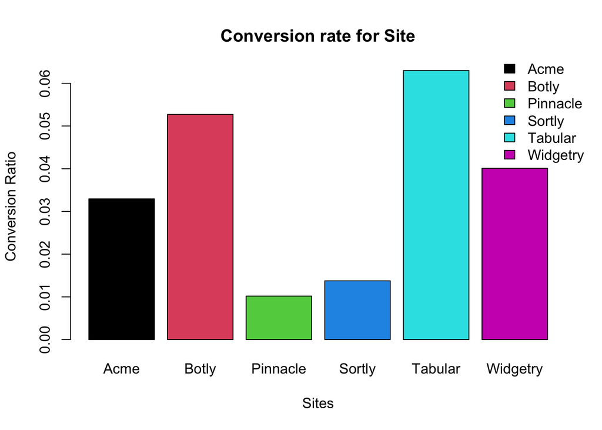

```r
barplot(visitsPerSite$conversion_rate,
        legend=factor(visitsPerSite$site),
        main = "Conversion rate for Site",
        xlab = "Sites",
        ylab = "Conversion Ratio",
        names.arg = visitsPerSite$site,
        col = factor(visitsPerSite$site),
        horiz = FALSE,
        args.legend = list(x = "topright", bty = "n", inset=c(-0.05, -0.07)))
```

this visualization shows us clearly that `Tabular` site is giving best results in terms of conversion above `6%` where as `Pinnacle` site is least effective in converting a visit to sale, comparatively `Botly` and `Widgetry` are fairing better than `Acme` , `Pinnacle` and `Sortly`.

Lets now take `Date` also in consideration and find out Monthly spread of visits for each site

```r
visitsPerSitePerDay<-aggregate(assignmentDataset$visits,by=assignmentDataset[c("day","site")],FUN=sum)

str(visitsPerSitePerDay)
```

```
## 'data.frame':    1608 obs. of  3 variables:
##  $ day : POSIXct, format: "2013-01-01" "2013-01-02" ...
##  $ site: chr  "Acme" "Acme" "Acme" "Acme" ...
##  $ x   : num  141604 152395 155523 143409 144395 ...
```

```r
monthlySiteVisits<-visitsPerSitePerDay%>%mutate(month = as.integer(format(day, "%m"))) %>%group_by(month, site)%>%summarise(total = sum(x))
str(monthlySiteVisits)
```

```
## tibble [54 × 3] (S3: grouped_df/tbl_df/tbl/data.frame)
##  $ month: int [1:54] 1 1 1 1 1 1 2 2 2 2 ...
##  $ site : chr [1:54] "Acme" "Botly" "Pinnacle" "Sortly" ...
##  $ total: num [1:54] 4365335 31188 82981 220946 84523 ...
##  - attr(*, "groups")= tibble [9 × 2] (S3: tbl_df/tbl/data.frame)
##   ..$ month: int [1:9] 1 2 6 7 8 9 10 11 12
##   ..$ .rows: list<int> [1:9]
##   .. ..$ : int [1:6] 1 2 3 4 5 6
##   .. ..$ : int [1:6] 7 8 9 10 11 12
##   .. ..$ : int [1:6] 13 14 15 16 17 18
##   .. ..$ : int [1:6] 19 20 21 22 23 24
##   .. ..$ : int [1:6] 25 26 27 28 29 30
##   .. ..$ : int [1:6] 31 32 33 34 35 36
##   .. ..$ : int [1:6] 37 38 39 40 41 42
##   .. ..$ : int [1:6] 43 44 45 46 47 48
##   .. ..$ : int [1:6] 49 50 51 52 53 54
##   .. ..@ ptype: int(0)
##   ..- attr(*, ".drop")= logi TRUE
```

```r
monthlySiteVisits
```

```
## # A tibble: 54 x 3
## # Groups:   month [9]
##    month site       total
##    <int> <chr>      <dbl>
##  1     1 Acme     4365335
##  2     1 Botly      31188
##  3     1 Pinnacle   82981
##  4     1 Sortly    220946
##  5     1 Tabular    84523
##  6     1 Widgetry  125768
##  7     2 Acme     3362921
##  8     2 Botly      27527
##  9     2 Pinnacle   60572
## 10     2 Sortly    179241
## # … with 44 more rows
```

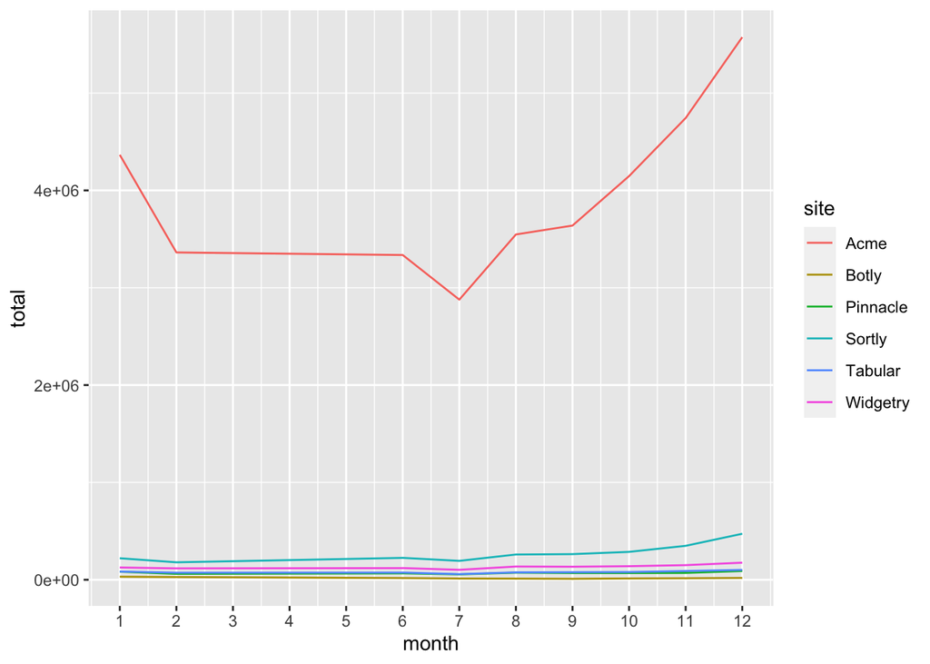

```r
ggplot(data = monthlySiteVisits, aes(x=month, y=total)) + geom_line(aes(colour=site))+scale_x_continuous(breaks = seq(1,12, by = 1))
```

we see that most visits are visible for `Acme` site,However the difference is far higher than other sites, thus in same plot monthly fluctuations on other sites are not apparent anymore, we will filter out visits from `Acme` and plot the view again

```r
monthlyVisitsWithoutAcme <-monthlySiteVisits%>%filter(site!="Acme")
monthlyVisitsWithoutAcme
```

```
## # A tibble: 45 x 3
## # Groups:   month [9]
##    month site      total
##    <int> <chr>     <dbl>
##  1     1 Botly     31188
##  2     1 Pinnacle  82981
##  3     1 Sortly   220946
##  4     1 Tabular   84523
##  5     1 Widgetry 125768
##  6     2 Botly     27527
##  7     2 Pinnacle  60572
##  8     2 Sortly   179241
##  9     2 Tabular   72488
## 10     2 Widgetry 116626
## # … with 35 more rows
```

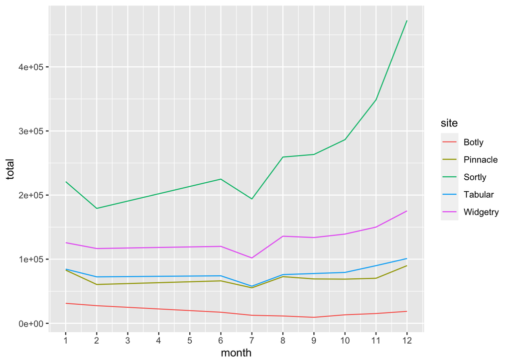

```r
ggplot(data = monthlyVisitsWithoutAcme, aes(x=month, y=total)) + geom_line(aes(colour=site))+scale_x_continuous(breaks = seq(1,12, by = 1))
```

Observing the visualization of visits per site per month, we conclude that

```
  - February and July months are having drop in visits, thus more marketing/advertising required in these months
  - December month has higher visits, thus site hosting infrastructure need to be prepared for the load
  - `Sortly` site visits are increasing by high rate with the end of the year, `Acme` site's growth rate is much higher compared to others
  - `Tabular` site which we know has highest conversion rate is not receiving higher visits, thus more marketing/advertising to be invested on promotion of this site as compared to others
```

**12. Consider the same dataset as earlier. Now perform bi-variate data analysis as discussed in last class to find out relationships between different variables. Write a short description on what you find in the analyses along with any tables, graphs. You do not have to analyse all variables, any 3‐4 variables that interest you most should be the focus here.**

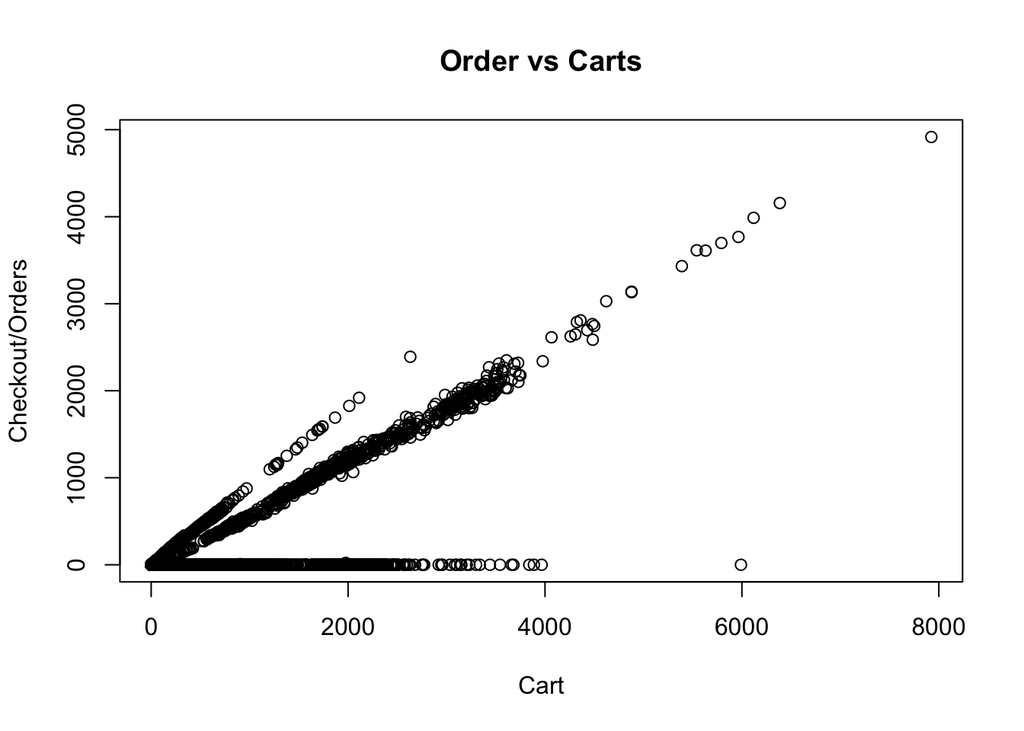

```r
#Answer of Q12

#correlating Checkouts done i.e orders made vs carts created
plot(assignmentDataset$add_to_cart, assignmentDataset$orders, main="Order vs Carts", xlab="Cart", ylab="Checkout/Orders")
```

We have information of Platform from where end user is accessing the sites, we also have bounces and visits for each site - if we plot bounces per visit aggregated by every distinct platform, we can understand browse behaviour of users with respect to each platform, thus

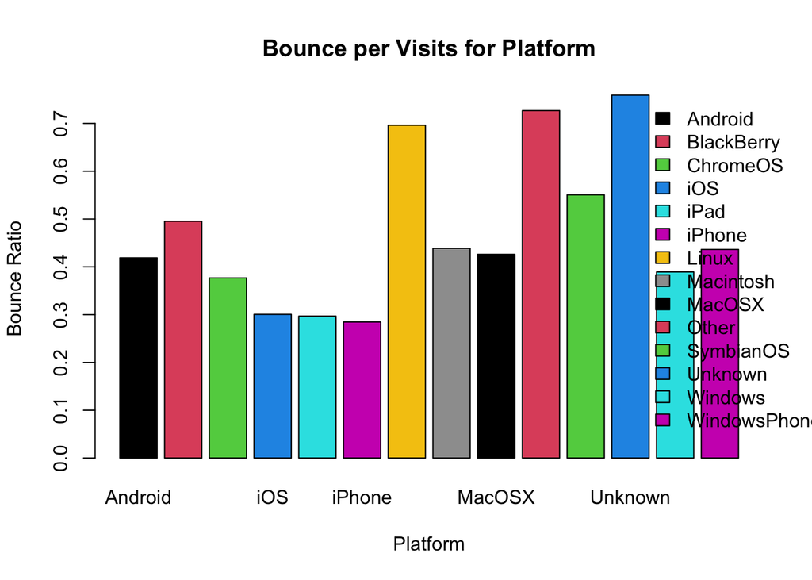

```r
#Correlating Platform vs Bounces - this is indicative of bug on site specific to a platform
platformBounces<-aggregate(assignmentDataset[c("bounces","visits")],
                           by=assignmentDataset["platform"],FUN=sum)

platformBounces["BPerV"] = platformBounces$bounces/platformBounces$visits
barplot(platformBounces$BPerV,
        legend=factor(platformBounces$platform),
        main = "Bounce per Visits for Platform",
        xlab = "Platform",
        ylab = "Bounce Ratio",
        names.arg = platformBounces$platform,
        col = factor(platformBounces$platform),
        horiz = FALSE,
        args.legend = list(x = "topright", bty = "n", inset=c(-0.10, 0)))
```

This plot shows which platform has high bounce rates - As this can be indicative of platform specific behavior of site, this report can be taken out after every periodic release upgrade to infer if there is any platform specific issues faced by end user,As when bounce rate becomes high on given day for specific platform, it will mean that site has some bugs for that platform. Alternatively this report can be taken out to perform A/B testing after rolling out some specific feature on individual platform

likewise, several other correlation can be established to infer different relationship between observations and a hypothesis can be build and validated with next set of data.

=====================================================================================================================